# Loan Eligibility Automation Project

## Introduction:

In today's volatile financial market, automation is critical to remaining competitive. BC Finance, a prominent home loan provider, plans to streamline the loan qualifying process. This project intends to use machine learning to determine eligibility based on consumer information such as gender, marital status, and income. BC Finance wants to use a methodical way to better target eligible consumers, eventually providing a model-driven solution via a web application.

Link to GitHub repository: [Click Here](https://github.com/Tiaan-Botes/Loan_elegibility_Confirmation_GroupE.git)

## Problem statement:

The problem is automating the loan eligibility process for a finance company based on customer data provided in an online application form. The company's goal is to create a real-time system that efficiently evaluates whether a customer is eligible for a mortgage loan. Key customer information includes gender, marital status, education, number of dependents, income, loan amount, credit history, and other relevant factors. By automating this process, the company aims to streamline operations, reduce manual effort, and improve the customer experience through faster response times to loan applications. Ultimately, it is important to identify specific customer segments for different loan amounts, allowing for targeted marketing efforts and efficient resource allocation.

## Data needed:

• Gender: The gender of the applicant

• Marital Status: The marital status of the applicant

• Education: The education level of the applicant

• Number of Dependents: The number of dependents the applicant has.

• Income: The income of the applicant, which is a crucial factor in determining loan eligibility.

• Loan Amount: The amount of loan the applicant is requesting.

• Credit History: The credit history of the applicant, indicating past repayment behavior.

• Other relevant factors: Additional factors such as employment status, property ownership, existing loans, etc., may also be considered depending on the company's criteria.

## Hypothesis:

1. Education level and monthly income positively impact the loan eligibility.
2. A higher number of dependents may negatively influence loan eligibility due to increased financial responsibilities.
3. Applicants with a better credit history are more likely to be eligible for higher loan amounts.
4. There is a correlation between loan amount and eligibility, with higher loan amounts being more difficult to obtain.
5. Gender and marital status do not have a significant impact on loan eligibility (to ensure fairness and avoid bias). These hypotheses will be tested during the exploratory data analysis and model building phases of the project.

## Data Collection and Cleaning the Data

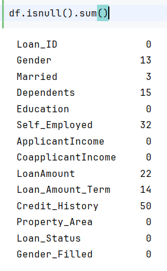

When finished identifying the columns with null values we now handle missing values by replacing them with their mean, mode, and median. For categorical data, the mode was chosen and for numeric data, the mean and median came into play. With this method, we avoid having columns without any values. Before getting the mode, we must identify how many variables are in that column. For example:

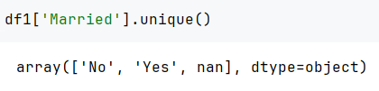

The next step is to get the mode of the column, the result was that the mode for ‘Married’ = yes:

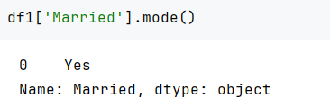

The final step is to replace the missing values with the mode. The result will show that there are no null values in the Married column anymore.

[figure not shown]

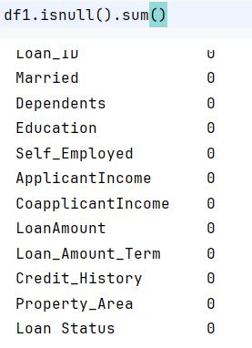

## Pre-Process and Transformation

Data processing prepares raw data for analysis, modeling, or machine learning. This involves cleaning and transforming data to make it suitable for further processing. Identifying outliers to detect and determine the range of values in the different columns in the data set. Outliers are extreme values that differ significantly from other data points in the given data set.

It is important we carefully identify the potential outliers that are in the dataset and handle them appropriately for accurate results. Identifying the range for the dataset:

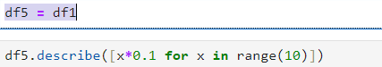

The result shows the ranges for the numeric data:

[figure not shown]

To show the graphical representation of the about data we have a box plot showing the outliers for the applicant's income.

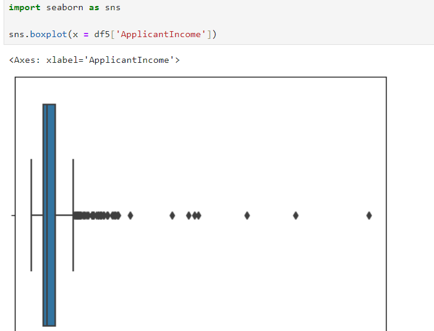

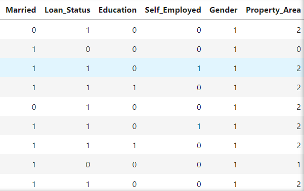

## Decision Tree Model:

### Import Libraries:

```python
import pandas as pd
from sklearn.model_selection import train_test_split
from sklearn.tree import DecisionTreeClassifier, plot_tree
from sklearn.metrics import accuracy_score
import plotly.express as px
import matplotlib.pyplot as plt
```

This code imports the libraries required for data processing, model assessment, and visualisation. It uses pandas to handle data, scikit-learn's train_test_split to split datasets, DecisionTreeClassifier for decision tree modelling, and plot_tree to visualise decision trees. It also imports accuracy_score for model assessment. Furthermore, it uses Plotly Express for interactive data visualisation and matplotlib.pyplot for static charting. These libraries work together to assist many stages of the machine learning workflow, including data preparation, model training, assessment, and visualisation.

### Next we prepared the data for the model:

```python
df = pd.read_csv('Loans updated2.csv')
df.drop(columns=['Loan_ID'], inplace=True)
ohe = pd.get_dummies(df, columns=['Dependents', 'ApplicantIncome', 'CoapplicantIncome', 'LoanAmount', 'Loan_Amount_Term',
                                  'Credit_History', 'Married', 'Loan_Status', 'Education',
                                  'Self_Employed', 'Gender', 'Property_Area'])
X = df.drop('Loan_Status', axis=1)
y = df['Loan_Status']
X_train, X_val, y_train, y_val = train_test_split(X, y, test_size=0.2, random_state=42)
```

### Calculating Baseline Accuracy

```python
acc_baseline = y_train.value_counts(normalize=True).max()
print("Baseline Accuracy:", round(acc_baseline, 2))
```

[output not shown]

This code calculates baseline accuracy by finding the fraction of the majority class in the training dataset's target variable and displays it as "Baseline Accuracy" rounded to two decimal places.

### Training and fine tuning the Decision Tree

```python
depth_hyperparams = range(1, 16)
training_acc = []
validation_acc = []

for d in depth_hyperparams:
    model_dt = DecisionTreeClassifier(max_depth=d, random_state=42)
    model_dt.fit(X_train, y_train)
    training_acc.append(model_dt.score(X_train, y_train))
    validation_acc.append(model_dt.score(X_val, y_val))
```

The term 'depth_hyperparams' refers to a set of values ranging from 1 to 15. Two empty lists, 'training_acc' and 'validation_acc', are created. Then, a loop iterates over each value in 'depth_hyperparams', where a decision tree classifier model is created with the current depth ('d') and trained on the training data ('X_train' and 'y_train'). The model's training and validation accuracy scores are calculated using the'score' method and appended to the lists 'training_acc' and 'validation_acc', respectively.

### Visualization of Training and Validation Curves

```python
tune_data = pd.DataFrame({'Training': training_acc, 'Validation': validation_acc}, index=depth_hyperparams)
fig = px.line(data_frame=tune_data, x=depth_hyperparams, y=['Training', 'Validation'], title="Training & Validation Curves (Decision Tree Model)")
fig.update_layout(xaxis_title="Maximum Depth", yaxis_title="Accuracy Score")
fig.show()
```

[output not shown]

This code section generates a pandas DataFrame called tune_data to hold training and validation accuracy ratings for different levels of a decision tree model. Using Plotly Express, it creates a line plot demonstrating how these accuracy scores vary as the decision tree's maximum depth changes. The x-axis depicts the greatest depth values, while the y-axis shows the training and validation accuracy scores. The plot's title is set to "Training & Validation Curves (Decision Tree Model)", and the axis labels are correctly titled. This visualisation helps to determine the best maximum depth for the decision tree model by showing how training and validation accuracies change with depth.

### Final Decision Tree visualization

```python
feature_names = X.columns
plt.figure(figsize=(18, 12))
plot_tree(decision_tree=final_model_dt, filled=True, max_depth=2, feature_names=feature_names, class_names=True)
plt.axis('off')
plt.show()
```

[output not shown]